HITS & HOMERS: A STATISTICAL LOOK AT

MLB’s BEST HITTERS

STOCKTON NELSON

and

ISAAC MILLER

and

COOPER RIGGS

April 14, 2025

Abstract

In Major League Baseball, teams are always seeking ways to gain a competitive edge.

By evaluating various variables in a player’s proﬁle, it’s possible to predict how he is

likely to contribute on the ﬁeld. We wanted to answer two key questions. First, how

are oﬀensive performance metrics—such as slugging percentage, on-base percentage,

plate appearances, and strikeout rate—related to both the number of home runs and

a player’s batting average over a season? Our other question was, how do the factors

associated with hitting more home runs diﬀer from those associated with achieving a

higher batting average, and what does this reveal about the distinct skills involved in

power hitting versus consistent contact? To answer these, we created two models using

a large dataset of hitting statistics from Baseball-Reference. We found that many of

the predictors in the dataset were highly correlated, which initially hindered model

accuracy. However, after accounting for multicollinearity, we developed models that

incorporate numerous quantitative and a few categorical variables to eﬀectively predict

a player’s batting average and home run totals.

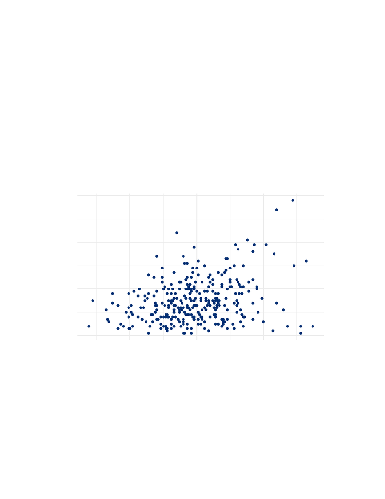

1 Introduction

In baseball, oﬀensive success is often summarized by just a few key statistics—most no-

tably, a player’s batting average and number of home runs. While both metrics are used

to evaluate hitting performance, they reﬂect distinct aspects of a player’s oﬀensive skill:

batting average captures consistency in making contact and reaching base, while home runs

represent raw power and the ability to change the game with a single swing. Understanding

what inﬂuences each of these outcomes is valuable not only for fans and analysts but also

for coaches, scouts, and front oﬃces aiming to evaluate and develop talent more eﬀectively.

In this study, we explore how a range of oﬀensive performance measures—such as slugging

percentage, on-base percentage, plate appearances, and strikeout rate—relate to both bat-

ting average and home run totals across MLB players. Speciﬁcally, we investigate: (1) how

oﬀensive performance metrics are related to both the number of home runs and a player’s

batting average over a season; and (2) how the factors associated with hitting more home

runs diﬀer from those associated with achieving a higher batting average, and what this

reveals about the distinct skills involved in power hitting versus consistent contact.

0

20

40

60

0.20 0.25 0.30

Batting Average

Home Runs

Batting Average vs. Home Runs

Figure 1: Scatterplot of Home Runs by Batting Average.

1.1 Data Description

This dataset was obtained from Baseball Reference and includes season-long batting statis-

tics for the top 300 Major League Baseball (MLB) players in the 2024 regular season, ranked

by batting average. Each row in the dataset represents a single player’s full-season batting

performance, making the observational unit a player-season. The variables capture a range

of oﬀensive statistics, including measures of hitting eﬃciency (e.g., slugging percentage and

on-base percentage), power hitting (e.g., home runs, doubles, and triples), and baserunning

1

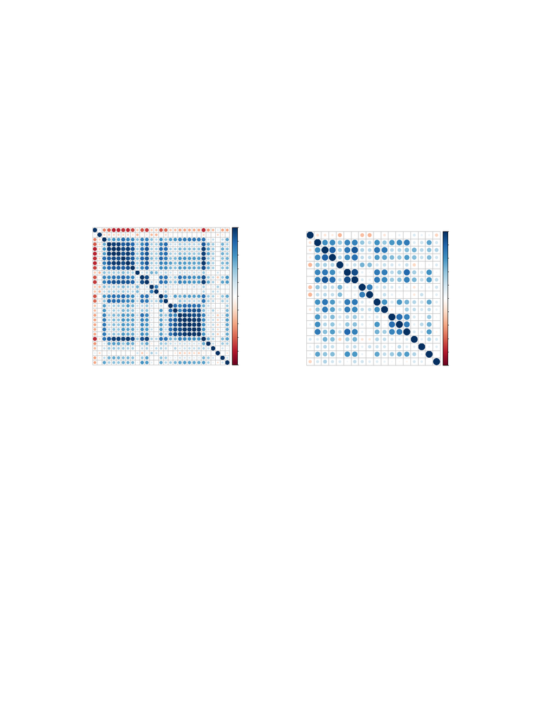

(e.g., stolen bases and total bases). Most variables are either raw counts (e.g., home runs,

doubles, stolen bases) or percentages (e.g., batting average, slugging percentage). These

statistics provide a detailed view of player performance and are used to investigate which

aspects of oﬀensive play are most closely associated with outcomes like batting average and

home run totals.

To better understand the nature of the data, it’s helpful to know that most hitters in this

group have a batting average between .200 and .270, with standout performers exceeding

.300. In terms of home runs, most players hit between 8 and 20 in the season, while top

power hitters reach 30 or more. Additionally, many of the oﬀensive statistics in baseball are

variations or combinations of one another, resulting in high correlations among predictors.

This multicollinearity raised concerns during modeling and motivated the use of regularized

regression methods such as LASSO.

−1

−0.8

−0.6

−0.4

−0.2

0

0.2

0.4

0.6

0.8

1

Rk

Age

WAR

G

PA

AB

R

H

X2B

X3B

HR

RBI

SB

CS

BB

SO

BA

OBP

SLG

OPS

OPS.

rOBA

Rbat.

TB

GIDP

HBP

SH

SF

IBB

Rk

Age

WAR

G

PA

AB

R

H

X2B

X3B

HR

RBI

SB

CS

BB

SO

BA

OBP

SLG

OPS

OPS.

rOBA

Rbat.

TB

GIDP

HBP

SH

SF

IBB

(a) All variables Correlation Matrix

−1

−0.8

−0.6

−0.4

−0.2

0

0.2

0.4

0.6

0.8

1

age

war

pa

doubles

triples

hr

rbi

steals

cs

bb

so

ba

obp

slg

gidp

hbp

ibb

sac

age

war

pa

doubles

triples

hr

rbi

steals

cs

bb

so

ba

obp

slg

gidp

hbp

ibb

sac

(b) Updated Correlation Matrix

Figure 2: Side-by-side correlation matrices showing (a) the correlation matrix with all the

variables in the dataset and (b) an updated correlation matrix after getting rid of correlated

variables.

2 Model Selection and Validation

For the study, our goal was to select the best models possible to predict batting average

and home runs. To do this, we ﬁrst selected models ourselves that we thought would work

to predict batting average and home runs. We then ran AIC and BIC best subsets, and

LASSO each twice on our large dataset of baseball statistics, once to create predictor models

for batting average and once to create predictor models for home runs, thus creating four

candidate models each for predicting batting average and for predicting home runs. Finally,

we ran cross validation twice, once on the batting average models to select the best of the

four options for batting average and once on the home run models to select the best for

home runs.

Here we will show ﬁrst the model we originally tested for batting average, then the one

we selected for batting average after running cross-validation. Then we will show the same

for home runs.

2

This is our test model for batting average. We chose this because we felt that a player

that walks a lot and gets on base a lot also would likely have a high batting average.

Similarly, getting lots of RBI usually indicates getting a lot of hits, which would also

contribute to having a higher batting average:

BattingAverage

i

= β

0

+β

1

× Walks

i

+ β

2

× RBI

i

+ β

3

× OBP

i

+ ϵ

i

,

(1)

where

ϵ

i

∼ N(0, σ

2

).

After running cross-validation, the model we ultimately selected to predict batting av-

erage was the LASSO-produced model, which is as follows:

BattingAverage

i

= β

0

+ β

1

× WAR

i

+ β

2

+ β

3

× Doubles

i

+ β

4

× Walks

i

+β

5

× Strikeouts

i

+ β

6

× OBP

i

+ β

7

× SLG

i

+ β

8

× GroundedIntoDoublePlay

i

+ β

9

× HitByPitch

i

+β

10

× SacFlies

i

+ β

11

× I(Divison

i

= ALWest) + β

12

× I(Division

i

= NLEast) + ϵ

i

,

(2)

where

ϵ

i

∼ N(0, σ

2

).

From the cross validation we did for Batting Average models, the LASSO-picked model

came out to be the one with the lowest bias, and had the same amount of predictors as the

AIC model; thus, we chose to use this model for batting average.

This is our test model for predicting home runs. We chose these predictors because we

thought that having a high batting average could indicate that a hitter would also be good

at hitting home runs; SLG and RBI usually indicate a player getting lots of extra-base hits;

strikeouts indicate a player taking more risks in at-bats; and Walks indicate a hitter being

able to see well where the ball is:

HomeRuns

i

= β

0

+β

1

× BattingAverage

i

+ β

2

× SLG

i

+ β

3

× RBI

i

+β

3

× Strikeouts

i

+ β

3

× Walks

i

+ ϵ

i

,

(3)

where

ϵ

i

∼ N(0, σ

2

).

The Model we chose for predicting home runs, after cross-validation:

HomeRuns

i

= β

0

+ β

1

× WAR

i

+ β

3

× Doubles

i

+ β

4

× Triples

i

+β

5

× RBI

i

+ β

6

× Walks

i

+ β

7

× Strikeouts

i

+β

8

× OBP

i

+ β

9

× SLG

i

+ β

10

× HitByPitch

i

+β

11

× SacriﬁceHits

i

+ β

12

× IntentionalWalks

i

+β

13

× I(Division

i

= NLCentral) + ϵ

i

,

(4)

where

ϵ

i

∼ N(0, σ

2

).

Based on the cross validation for our Home Run models, the AIC model clearly had the

lowest prediction error (PMSE) and the closest-to-zero bias; thus, we chose to use the AIC

3

[figure not shown]

model to predict home runs.

We had originally selected models using predictors from the entire dataset; however,

upon checking for assumptions, we found that several were not being met—including mul-

ticollinearity, normality, inﬂuential points, and equal variance. Because of this, we had

to remove some variables from the dataset and re-do the process of selecting our models,

which resulted in models that ﬁt the assumptions. One way we also addressed this was by

using LASSO regression, which improves model accuracy and interpretability by shrinking

some coeﬃcients to zero, eﬀectively performing variable selection. Unlike stepwise or best

subsets methods, LASSO can handle many predictors at once and is more stable in the

presence of multicollinearity, making it more useful for building simpler, more generalizable

models.

3 Analyses, Results, and Interpretation

Table 1: Regression Output for Batting Average Model

Estimate t value p-value Lower 95% Upper 95%

(Intercept) -0.00866 -0.96595 0.33485 -0.02631 0.00899

WAR 0.00274 5.12147 0.00000 0.00169 0.00380

Doubles 0.00101 8.84421 0.00000 0.00078 0.00123

BB -0.00107 -18.51070 0.00000 -0.00118 -0.00095

SO 0.00002 0.69392 0.48827 -0.00003 0.00007

OBP% 0.00808 23.28547 0.00000 0.00740 0.00876

SLG% 0.00030 1.82021 0.06973 -0.00002 0.00062

GIDP 0.00071 4.83644 0.00000 0.00042 0.00101

HBP -0.00139 -8.49005 0.00000 -0.00171 -0.00107

SAC 0.00088 3.87427 0.00013 0.00043 0.00132

AL West 0.00004 0.02260 0.98198 -0.00331 0.00339

NL East 0.00134 0.82068 0.41248 -0.00187 0.00456

The results of the batting average model (Table 1) show us some interesting things about

contributions to a player’s batting average in the most recent season. The most inﬂuential

predictor was on-base percentage. With a very low p-value we can assume that on-base

percentage is signiﬁcant in predicting batting average. In fact, we are 95% conﬁdent, holding

all other variables constant, that for every .010 increase in a player’s on-base percentage his

batting average will increase, on average, between .007 and .009. Due to the narrowness of

this interval we can be very conﬁdent in on-base percentage as a predictor of batting average.

This makes sense because when a player gets a hit it contributes positively to both their

batting average and their on-base percentage. Interestingly, the results show that walks

are negatively associated with batting average. We are 95% conﬁdent that, on average, for

every walk a player has their batting average will decrease between .001 and .0009, holding

all the other variables constant. While this isn’t a large change in batting average it is still

a very narrow interval, which shows that walks are a signiﬁcant contributor in decreasing a

player’s batting average. Other results we found are that slugging percentage, while in the

prediction model, gives us 95% conﬁdence, while holding all else constant, that for every

.010 increase in slugging percentage a player’s batting average changes between -0.00002

and 0.0006, on average. This means that we cannot claim that slugging percentage has

a real eﬀect on batting average. This is interesting because with 95% conﬁdence we can

4

[figure not shown]

say that, holding all else constant, for every double a player hits their batting average will

increase, on average, by 0.0007 and 0.001, showing that doubles has a signiﬁcant eﬀect on

batting average while slugging percentage, which doubles contributes to, does not have a

signiﬁcant eﬀect. From these results it can be safe to say that players that make consistent

contact, rather than hitting for power are more likely to increase their batting average.

Table 2: Regression Output for Home Run Model

Estimate t value p-value Lower 95% Upper 95%

(Intercept) 1.654 1.030 0.304 -1.507 4.814

WAR 0.455 4.665 0.000 0.263 0.647

Doubles -0.179 -8.783 0.000 -0.219 -0.139

Triples -0.444 -7.936 0.000 -0.554 -0.334

RBI 0.147 13.298 0.000 0.125 0.168

BB 0.167 14.238 0.000 0.144 0.191

SO 0.027 5.897 0.000 0.018 0.036

OBP% -1.161 -17.222 0.000 -1.294 -1.029

SLG% 0.884 24.524 0.000 0.813 0.955

HBP 0.154 5.204 0.000 0.096 0.212

IBB 0.182 3.221 0.001 0.071 0.293

SAC -0.137 -3.255 0.001 -0.220 -0.054

NL Central -0.465 -1.632 0.104 -1.026 0.096

The results of our Home run model (Table 2) show us what contributes to a player’s home

run total in the most recent season. We can see from the results that slugging percentage is

the most important factor in a player’s home run total. We are 95% conﬁdent, while holding

all else constant, that an increase of .010 in a player’s slugging percentage, will increase their

home run total between .813 and .955, on average. This shows that slugging percentage

contributes greatly to a player’s home run total. Another interesting result is that all types

of walks (BB, HBP, and IBB) are all positively signiﬁcant contributors to home run total.

For example, with 95% conﬁdence, holding all the other variables constant, we can say that

for every walk a player’s home run total, on average, will increase between 0.144 and 0.191.

Over the course of the season walks can start to add up, so it’s interesting to see that a

player who has 80 walks in a season would, on average, have a home run total 11.5 to 15

home runs higher. Not only do walks contribute positively to home run total, but we also

found that we are 95% conﬁdent, holding all else constant, for every strikeout a player’s

home run total will increase, on average, between 0.018 and 0.036. While it is a smaller

number than walks, it is interesting to see that strikeouts have a signiﬁcant positive eﬀect

on home run total. Finally, we found that doubles, triples, and on-base percentage, while

assumed to have a positive eﬀect on home run total actually have a negatively signiﬁcant

eﬀect on home run total, with each of these variables having very small p-values we have

suﬃcient evidence to claim this. In fact, with 95% conﬁdence we claim, while holding all

else constant, that for every triple hit a player’s home run total will decrease, on average,

between 0.334 and 0.554 home runs.

As we looked at the results of our home run model, we noticed that there were a couple

of somewhat inﬂuential points in the model. These points were two players who led the

MLB in home runs last season, Aaron Judge and Shohei Ohtani. We were curious if our

model performance would improve if these two players were removed from the model. Thus,

we removed them and ran a new model without Judge and Ohtani. With the results of our

5

ﬁrst model (Table 2) and the results of our new model without the inﬂuential players we

compared predictive metrics such as adjusted R

2

, RMSE, AIC, and BIC. What we found

was that the new model produced lower RMSE, AIC, and BIC. For example, the AIC for

the ﬁrst model was 1273.6 and for the new model it was 1249.8, with the diﬀerence being

23.8 showing that there is a signiﬁcant diﬀerence in the two models, suggesting that the

new model is better at predicting home run totals than the ﬁrst model. We also found that

the new model had an RMSE of 1.76 and the ﬁrst model had an RMSE of 1.80, showing

that the new model, on average, predicted better than the ﬁrst model. While the new

model didn’t predict much better than the ﬁrst model, our predictive metrics still showed

that the new model performed better. This allows us to conclude that Shohei Ohtani and

Aaron Judge overachieved in their home run totals given their other oﬀensive performance

metrics, justifying both players winning MVP in their respective leagues last season.

4 Conclusions

Overall, through our analysis we made several interesting ﬁndings about what statistics

most predict batting average and home runs for a given baseball player in a season. Orig-

inally, our questions were about ﬁnding these variables, and also whether the predictors

for batting average and home runs are diﬀerent, or if many of their predictors overlap.

We found that for batting average, OBP was the most inﬂuential predictor, with walks as

the second most inﬂuential, negatively inﬂuencing batting average. This was interesting

because walks contribute to OBP as well. Notably, doubles also contributed strongly to

batting average. For home runs, RBI, Walks, and SLG were the strongest that contirbuted

positively, while OBP was the most inﬂuential predictor that cotributed negatively. One

variable that positively predicted both was WAR, however, it seemed that most of the

variables that positively inﬂuenced batting average, negatively inﬂuenced home runs, and

vice versa. From this we can conclude that overall the predictors for batting average and

home runs are largely diﬀerent, showing that overall the required skillsets in players are

quite diﬀerent for high batting average and high home runs, respectively. However there are

some weaknesses with our models that could be problematic for our results. For example,

grounding into double plays was a signiﬁcant positive predictor for batting average in our

analysis. That said, clearly grounding into double plays should not be recommended for

any player to improve their batting average. In a similar fashion, we found strikeouts were

a signiﬁcant positive predictor for home runs. While many of the predictors we found are

valuable to know for predicting batting average and home runs, it is still important to look

at the results logically.

6

APPENDIX

Prompts:

• I am reporting on a regression and I am looking for feedback on my report. I have a

few things I want to look over, so I will go over each of them one by one. To start,

do the ideas connect throughout the paper?

• My report calls to write in the context of writing to a boss who has taken STAT 121

and STAT 330 and is familiar with some statistical concepts. For reference, STAT

121 is an intro to statistics class and STAT 330 is an introduction to linear regression.

Does the report with the changes we’ve made ﬁt into that context?

• Are the research questions proposed in the report answered?

Recommendations:

• Page 4 (Batting Average model explanation): The switch between the original model

and the LASSO model could be more explicitly contrasted. You could say something

like: ”While the initial model relied on intuition (e.g., Walks and RBIs), LASSO

oﬀered a broader, data-driven selection that improved predictive performance.”

– How We Incorporated It: Revised the beginning of this paragraph to ﬂow

better.

• Conclusion: This section is solid, but one sentence that begins with “However there

are some weaknesses. . . ” runs on a bit. Consider splitting or tightening it to make

the ideas punchier.

– How We Incorporated It: Revised this section to be split up better.

• You could soften one or two heavier stats terms (like “PMSE”) by quickly saying

what it means: “...the AIC model clearly had the lowest PMSE (prediction error)...”

– How We Incorporated It: We revised it so our boss can understand what we

are saying.

• You might also add brief intuitive reasoning behind LASSO in the model selection

section (e.g., “We chose LASSO because it works well when predictors are highly

correlated, helping simplify the model without losing accuracy.”)

– Why We Didn’t Incorporate It: We already had a section at the beginning

of page 4 which covers this.

• Both research questions are clearly answered.

– Why We Didn’t Incorporate It: Says that we have answered both questions.

7